# Ames Housing: Linear Regression Lab

Using property characteristics to support residential valuation

Analytics Solutions Bootcamp

07 September 2026

```r
knitr::opts_chunk$set(
  echo = TRUE,
  message = FALSE,
  warning = FALSE,
  fig.width = 9,
  fig.height = 5
)

required_packages <- c(
  "modeldata", "tidyverse", "janitor", "rsample",
  "broom", "yardstick", "scales"
)

missing_packages <- required_packages[
  !required_packages %in% rownames(installed.packages())
]

if (length(missing_packages) > 0) {
  stop(
    "Install the missing packages first: ",
    paste(missing_packages, collapse = ", ")
  )
}

library(modeldata)
library(tidyverse)
library(janitor)
library(rsample)
library(broom)
library(yardstick)
library(scales)

set.seed(123)
```

# 1 Business scenario

A residential property company needs a consistent starting point for estimating sale prices in Ames, Iowa. Agents currently rely heavily on comparable listings and individual judgment. Management wants to understand how much price variation can be explained by observable property characteristics and how large a typical valuation error may be.

The model will support—not replace—professional appraisal. Historical sale price is the numerical response variable, so this is a **regression problem**.

## 1.1 Operational questions

This lab answers the following questions:

1. What is the typical sale price, and how widely do prices vary?
2. How much does sale price generally change as above-ground living area grows?
3. Is living area alone sufficient for initial valuation?
4. Does including age, basement area, garage capacity, bathrooms, and neighborhood materially improve estimates?
5. What is the typical dollar error for each model?
6. Which model better supports preliminary pricing and appraisal triage?
7. Which properties sell substantially above or below their estimated values and may require manual investigation?
8. What limitations should management consider before operational use?

> **Important:** Regression coefficients describe historical associations while holding included predictors constant. They do not establish that changing a property feature will cause its price to change by the coefficient amount.

# 2 1. Load and understand the data

```r
data(ames, package = "modeldata")

ames_data <- ames |>
  clean_names()

glimpse(ames_data)
```

```
## Rows: 2,930
## Columns: 74
## $ ms_sub_class       <fct> One_Story_1946_and_Newer_All_Styles, One_Story_1946…
## $ ms_zoning          <fct> Residential_Low_Density, Residential_High_Density, …
## $ lot_frontage       <dbl> 141, 80, 81, 93, 74, 78, 41, 43, 39, 60, 75, 0, 63,…
## $ lot_area           <int> 31770, 11622, 14267, 11160, 13830, 9978, 4920, 5005…
## $ street             <fct> Pave, Pave, Pave, Pave, Pave, Pave, Pave, Pave, Pav…
## $ alley              <fct> No_Alley_Access, No_Alley_Access, No_Alley_Access, …
## $ lot_shape          <fct> Slightly_Irregular, Regular, Slightly_Irregular, Re…
## $ land_contour       <fct> Lvl, Lvl, Lvl, Lvl, Lvl, Lvl, Lvl, HLS, Lvl, Lvl, L…
## $ utilities          <fct> AllPub, AllPub, AllPub, AllPub, AllPub, AllPub, All…
## $ lot_config         <fct> Corner, Inside, Corner, Corner, Inside, Inside, Ins…
## $ land_slope         <fct> Gtl, Gtl, Gtl, Gtl, Gtl, Gtl, Gtl, Gtl, Gtl, Gtl, G…
## $ neighborhood       <fct> North_Ames, North_Ames, North_Ames, North_Ames, Gil…
## $ condition_1        <fct> Norm, Feedr, Norm, Norm, Norm, Norm, Norm, Norm, No…
```

[output cut: 61 more lines]

```r
tibble(
  properties = nrow(ames_data),
  variables = ncol(ames_data),
  duplicate_rows = sum(duplicated(ames_data)),
  missing_values = sum(is.na(ames_data))
)
```

```
## # A tibble: 1 × 4
##   properties variables duplicate_rows missing_values
##        <int>     <int>          <int>          <int>
## 1       2930        74              0              0
```

For this introductory lab, we use a small, interpretable subset of variables. This keeps the multiple-regression model aligned with the operational questions.

```r
housing_data <- ames_data |>
  transmute(
    sale_price,
    gr_liv_area,
    year_built,
    total_bsmt_sf,
    garage_cars,
    full_bath,
    neighborhood
  ) |>
  drop_na()

glimpse(housing_data)
```

```
## Rows: 2,930
## Columns: 7
## $ sale_price    <int> 215000, 105000, 172000, 244000, 189900, 195500, 213500, …
## $ gr_liv_area   <int> 1656, 896, 1329, 2110, 1629, 1604, 1338, 1280, 1616, 180…
## $ year_built    <int> 1960, 1961, 1958, 1968, 1997, 1998, 2001, 1992, 1995, 19…
## $ total_bsmt_sf <dbl> 1080, 882, 1329, 2110, 928, 926, 1338, 1280, 1595, 994, …
## $ garage_cars   <dbl> 2, 1, 1, 2, 2, 2, 2, 2, 2, 2, 2, 2, 2, 2, 2, 3, 2, 3, 2,…
## $ full_bath     <int> 1, 1, 1, 2, 2, 2, 2, 2, 2, 2, 2, 2, 2, 1, 1, 3, 2, 1, 1,…
## $ neighborhood  <fct> North_Ames, North_Ames, North_Ames, North_Ames, Gilbert,…
```

| Variable | Operational meaning |
| --- | --- |
| `sale_price` | Historical property sale price in US dollars |
| `gr_liv_area` | Above-ground living area in square feet |
| `year_built` | Original construction year |
| `total_bsmt_sf` | Total basement area in square feet |
| `garage_cars` | Approximate garage capacity in cars |
| `full_bath` | Number of full bathrooms above ground |
| `neighborhood` | Physical neighborhood classification |

# 3 2. Explore the housing market

## 3.1 Sale-price profile

```r
housing_data |>
  summarise(
    properties = n(),
    mean_price = mean(sale_price),
    median_price = median(sale_price),
    minimum_price = min(sale_price),
    maximum_price = max(sale_price),
    standard_deviation = sd(sale_price)
  )
```

```
## # A tibble: 1 × 6
##   properties mean_price median_price minimum_price maximum_price
##        <int>      <dbl>        <dbl>         <int>         <int>
## 1       2930    180796.       160000         12789        755000
## # ℹ 1 more variable: standard_deviation <dbl>
```

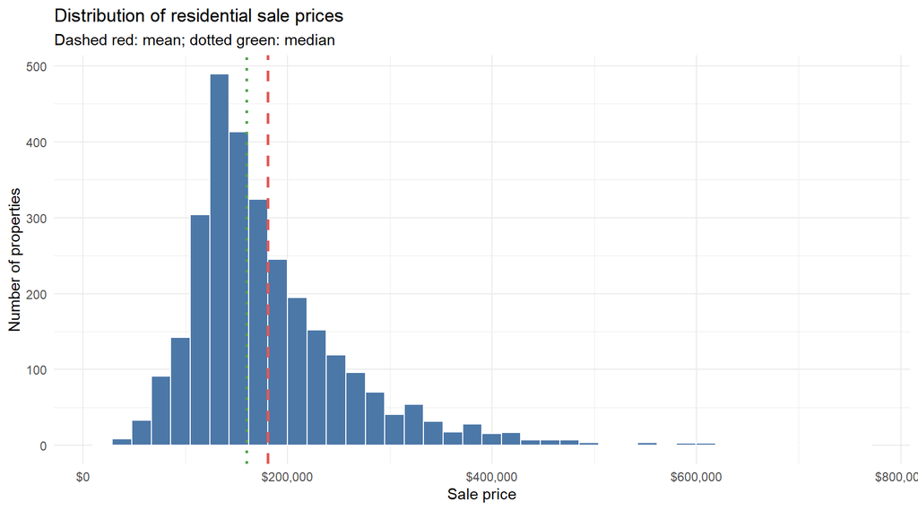

```r
price_mean <- mean(housing_data$sale_price)
price_median <- median(housing_data$sale_price)

ggplot(housing_data, aes(sale_price)) +
  geom_histogram(bins = 40, fill = "#4C78A8", color = "white") +
  geom_vline(
    xintercept = price_mean,
    color = "#E45756",
    linewidth = 1,
    linetype = "dashed"
  ) +
  geom_vline(
    xintercept = price_median,
    color = "#54A24B",
    linewidth = 1,
    linetype = "dotted"
  ) +
  scale_x_continuous(labels = dollar) +
  labs(
    title = "Distribution of residential sale prices",
    subtitle = "Dashed red: mean; dotted green: median",
    x = "Sale price",
    y = "Number of properties"
  ) +
  theme_minimal()
```

If the mean is much higher than the median, unusually expensive properties may be pulling the average upward. That affects both operational reporting and model errors.

## 3.2 Price and living area

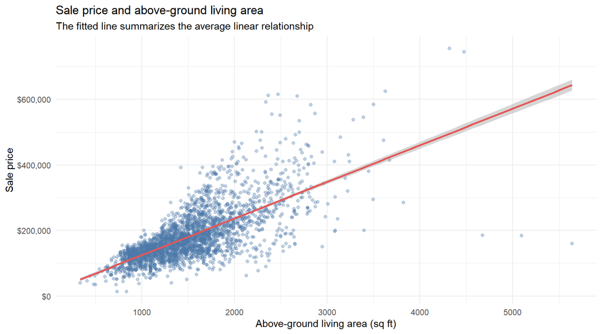

```r
ggplot(housing_data, aes(gr_liv_area, sale_price)) +
  geom_point(alpha = 0.35, color = "#4C78A8") +
  geom_smooth(method = "lm", se = TRUE, color = "#E45756") +
  scale_y_continuous(labels = dollar) +
  labs(
    title = "Sale price and above-ground living area",
    subtitle = "The fitted line summarizes the average linear relationship",
    x = "Above-ground living area (sq ft)",
    y = "Sale price"
  ) +
  theme_minimal()
```

```r
housing_data |>
  summarise(
    correlation = cor(gr_liv_area, sale_price),
    covariance = cov(gr_liv_area, sale_price)
  )
```

```
## # A tibble: 1 × 2
##   correlation covariance
##         <dbl>      <dbl>
## 1       0.707  28542200.
```

## 3.3 Price differences across neighborhoods

```r
neighborhood_summary <- housing_data |>
  group_by(neighborhood) |>
  summarise(
    sales = n(),
    median_price = median(sale_price),
    mean_price = mean(sale_price),
    .groups = "drop"
  ) |>
  arrange(desc(median_price))

neighborhood_summary
```

```
## # A tibble: 28 × 4
##    neighborhood       sales median_price mean_price
##    <fct>              <int>        <dbl>      <dbl>
##  1 Stone_Brook           51      319000     324229.
##  2 Northridge_Heights   166      317750     322018.
##  3 Northridge            71      302000     330319.
##  4 Green_Hills            2      280000     280000
##  5 Veenker               24      250250     248315.
##  6 Timberland            72      232106.    246600.
##  7 Somerset             182      225500     229707.
##  8 Crawford             103      200624     207551.
##  9 College_Creek        267      200000     201803.
## 10 Greens                 8      198000     193531.
## # ℹ 18 more rows
```

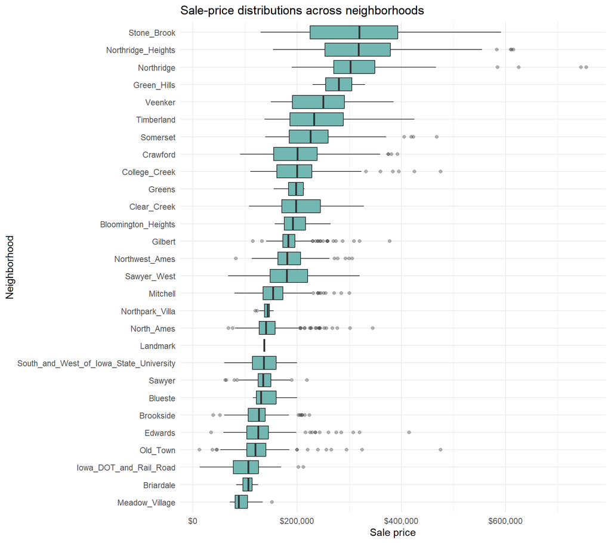

```r
ggplot(
  housing_data,
  aes(
    x = reorder(neighborhood, sale_price, FUN = median),
    y = sale_price
  )
) +
  geom_boxplot(fill = "#72B7B2", outlier.alpha = 0.35) +
  coord_flip() +
  scale_y_continuous(labels = dollar) +
  labs(
    title = "Sale-price distributions across neighborhoods",
    x = "Neighborhood",
    y = "Sale price"
  ) +
  theme_minimal()
```

### 3.3.1 Operational discussion

- Would a company-wide average be a useful estimate for every property?
- Which market segments contain the highest-value properties?
- Do properties with similar living areas always sell for similar prices?
- Which omitted features might explain the remaining variation?

# 4 3. Prepare training and test data

We split the data before fitting either model. Stratification by `sale_price` helps maintain a similar price distribution in both samples.

```r
ames_split <- initial_split(
  housing_data,
  prop = 0.80,
  strata = sale_price
)

train_data <- training(ames_split)
test_data <- testing(ames_split)

bind_rows(
  train_data |>
    summarise(
      dataset = "Training",
      properties = n(),
      mean_price = mean(sale_price),
      median_price = median(sale_price)
    ),
  test_data |>
    summarise(
      dataset = "Test",
      properties = n(),
      mean_price = mean(sale_price),
      median_price = median(sale_price)
    )
)
```

```
## # A tibble: 2 × 4
##   dataset  properties mean_price median_price
##   <chr>         <int>      <dbl>        <dbl>
## 1 Training       2342    179795.       160000
## 2 Test            588    184783.       160250
```

# 5 4. Establish a baseline estimate

Before regression, suppose the company estimates every test property using the mean training sale price. This gives a basic benchmark for evaluating whether property characteristics add useful information.

```r
training_mean_price <- mean(train_data$sale_price)

baseline_predictions <- test_data |>
  transmute(
    truth = sale_price,
    .pred = training_mean_price
  )

baseline_predictions |>
  summarise(
    model = "Training-mean baseline",
    mae = mae_vec(truth, .pred),
    mse = mse_vec(truth, .pred),
    rmse = rmse_vec(truth, .pred),
    rsq = rsq_vec(truth, .pred)
  )
```

```
## # A tibble: 1 × 5
##   model                     mae         mse   rmse   rsq
##   <chr>                   <dbl>       <dbl>  <dbl> <dbl>
## 1 Training-mean baseline 61001. 7426764887. 86179.    NA
```

# 6 5. Simple linear regression

The first model estimates sale price from above-ground living area alone:

$$\widehat{SalePrice} = \beta_0 + \beta_1(GrLivArea)$$

The fitted coefficients minimize the sum of squared residuals, where a residual is the difference between an observed price and its fitted price.

```r
simple_model <- lm(
  sale_price ~ gr_liv_area,
  data = train_data
)

summary(simple_model)
```

```
##
## Call:
## lm(formula = sale_price ~ gr_liv_area, data = train_data)
##
## Residuals:
##     Min      1Q  Median      3Q     Max
## -464967  -30158   -1854   22529  331135
##
## Coefficients:
##              Estimate Std. Error t value Pr(>|t|)
## (Intercept) 18253.026   3582.610   5.095 3.77e-07 ***
## gr_liv_area   107.535      2.258  47.621  < 2e-16 ***
## ---
## Signif. codes:  0 '***' 0.001 '**' 0.01 '*' 0.05 '.' 0.1 ' ' 1
##
## Residual standard error: 55760 on 2340 degrees of freedom
## Multiple R-squared:  0.4922, Adjusted R-squared:  0.4919
## F-statistic:  2268 on 1 and 2340 DF,  p-value: < 2.2e-16
```

## 6.1 Interpret the coefficients

```r
tidy(simple_model, conf.int = TRUE)
```

```
## # A tibble: 2 × 7
##   term        estimate std.error statistic     p.value conf.low conf.high
##   <chr>          <dbl>     <dbl>     <dbl>       <dbl>    <dbl>     <dbl>
## 1 (Intercept)   18253.   3583.        5.09 0.000000377   11228.    25278.
## 2 gr_liv_area     108.      2.26     47.6  0               103.      112.
```

Interpretation guide:

- **Intercept:** estimated price when living area is zero. This is needed to position the line mathematically, but it is not operationally meaningful because a zero-square-foot home is outside the useful data range.
- **Living-area coefficient:** expected difference in sale price associated with one additional square foot, on average.
- Multiplying the coefficient by 100 gives a more practical estimate for an additional 100 square feet.

```r
area_coefficient <- coef(simple_model)[["gr_liv_area"]]

tibble(
  additional_area_sq_ft = c(1, 100, 500),
  estimated_price_difference = area_coefficient * additional_area_sq_ft
)
```

```
## # A tibble: 3 × 2
##   additional_area_sq_ft estimated_price_difference
##                   <dbl>                      <dbl>
## 1                     1                       108.
## 2                   100                     10754.
## 3                   500                     53768.
```

This is an association, not a guaranteed return from constructing additional space. Quality, location, layout, and other factors may differ.

## 6.2 Generate test predictions

```r
simple_predictions <- test_data |>
  transmute(
    truth = sale_price,
    .pred = predict(simple_model, newdata = test_data),
    residual = truth - .pred
  )
```

# 7 6. Multiple linear regression

Living area does not capture the full valuation context. We extend the model:

$$\widehat{SalePrice} = \beta_0 + \beta_1X_1 + \beta_2X_2 + \cdots +
\beta_mX_m$$

The multiple model estimates the association of each predictor with price while holding the other included predictors constant.

```r
multiple_model <- lm(
  sale_price ~ gr_liv_area + year_built + total_bsmt_sf +
    garage_cars + full_bath + neighborhood,
  data = train_data
)

summary(multiple_model)
```

```
##
## Call:
## lm(formula = sale_price ~ gr_liv_area + year_built + total_bsmt_sf +
##     garage_cars + full_bath + neighborhood, data = train_data)
##
## Residuals:
##     Min      1Q  Median      3Q     Max
## -419891  -15879     311   14936  267490
##
## Coefficients:
##                                                       Estimate Std. Error
## (Intercept)                                         -9.250e+05  1.055e+05
## gr_liv_area                                          6.108e+01  2.229e+00
## year_built                                           4.821e+02  5.417e+01
## total_bsmt_sf                                        2.989e+01  2.113e+00
## garage_cars                                          1.467e+04  1.367e+03
## full_bath                                           -6.255e+03  2.004e+03
## neighborhoodCollege_Creek                            1.721e+04  3.662e+03
## neighborhoodOld_Town                                -2.332e+03  3.791e+03
## neighborhoodEdwards                                 -7.316e+03  3.449e+03
## neighborhoodSomerset                                 3.485e+04  4.262e+03
## neighborhoodNorthridge_Heights                       7.961e+04  4.537e+03
## neighborhoodGilbert                                  7.189e+03  4.307e+03
## neighborhoodSawyer                                  -9.308e+01  3.784e+03
## neighborhoodNorthwest_Ames                           3.230e+03  4.127e+03
## neighborhoodSawyer_West                              3.922e+03  4.324e+03
## neighborhoodMitchell                                 6.463e+02  4.333e+03
## neighborhoodBrookside                                9.469e+03  4.587e+03
## neighborhoodCrawford                                 4.329e+04  4.423e+03
## neighborhoodIowa_DOT_and_Rail_Road                  -3.250e+03  4.686e+03
## neighborhoodTimberland                               4.199e+04  5.527e+03
## neighborhoodNorthridge                               6.992e+04  5.642e+03
## neighborhoodStone_Brook                              9.975e+04  6.246e+03
## neighborhoodSouth_and_West_of_Iowa_State_University -1.995e+03  6.906e+03
## neighborhoodClear_Creek                              2.842e+04  6.439e+03
## neighborhoodMeadow_Village                          -1.791e+04  6.909e+03
## neighborhoodBriardale                               -1.555e+04  7.214e+03
## neighborhoodBloomington_Heights                      8.714e+03  8.048e+03
## neighborhoodVeenker                                  4.720e+04  8.510e+03
## neighborhoodNorthpark_Villa                         -6.014e+03  8.319e+03
```

[output cut: 29 more lines]

```
## neighborhoodMeadow_Village                           -2.593  0.00959 **
## neighborhoodBriardale                                -2.156  0.03119 *
## neighborhoodBloomington_Heights                       1.083  0.27904
## neighborhoodVeenker                                   5.547 3.24e-08 ***
## neighborhoodNorthpark_Villa                          -0.723  0.46982
## neighborhoodBlueste                                   0.253  0.80008
## neighborhoodGreens                                    2.794  0.00525 **
## neighborhoodGreen_Hills                               5.193 2.25e-07 ***
## neighborhoodLandmark                                 -0.424  0.67135
## ---
## Signif. codes:  0 '***' 0.001 '**' 0.01 '*' 0.05 '.' 0.1 ' ' 1
##
## Residual standard error: 35570 on 2309 degrees of freedom
## Multiple R-squared:  0.7961, Adjusted R-squared:  0.7933
## F-statistic: 281.7 on 32 and 2309 DF,  p-value: < 2.2e-16
```

## 7.1 Interpret selected coefficients

```r
multiple_coefficients <- tidy(
  multiple_model,
  conf.int = TRUE
) |>
  arrange(p.value)

multiple_coefficients
```

```
## # A tibble: 33 × 7
##    term                estimate std.error statistic   p.value conf.low conf.high
##    <chr>                  <dbl>     <dbl>     <dbl>     <dbl>    <dbl>     <dbl>
##  1 gr_liv_area           6.11e1      2.23     27.4  2.03e-143   5.67e1      65.5
##  2 neighborhoodNorthr…   7.96e4   4537.       17.5  8.23e- 65   7.07e4   88508.
##  3 neighborhoodStone_…   9.97e4   6246.       16.0  1.53e- 54   8.75e4  111995.
##  4 total_bsmt_sf         2.99e1      2.11     14.1  1.22e- 43   2.58e1      34.0
##  5 neighborhoodNorthr…   6.99e4   5642.       12.4  3.38e- 34   5.89e4   80984.
##  6 garage_cars           1.47e4   1367.       10.7  2.77e- 26   1.20e4   17354.
##  7 neighborhoodCrawfo…   4.33e4   4423.        9.79 3.44e- 22   3.46e4   51963.
##  8 year_built            4.82e2     54.2       8.90 1.11e- 18   3.76e2     588.
##  9 (Intercept)          -9.25e5 105519.       -8.77 3.50e- 18  -1.13e6 -718123.
## 10 neighborhoodSomers…   3.48e4   4262.        8.18 4.81e- 16   2.65e4   43204.
## # ℹ 23 more rows
```

Interpretation reminders:

- A numerical coefficient represents an expected price difference for a one-unit increase, holding the other included variables constant.
- A neighborhood coefficient is interpreted relative to the model’s reference neighborhood.
- A small p-value indicates evidence of an association under the model’s assumptions; it does not measure business importance or causality.
- Confidence intervals communicate uncertainty around each estimated coefficient.

```r
tibble(
  reference_neighborhood = levels(train_data$neighborhood)[1]
)
```

```
## # A tibble: 1 × 1
##   reference_neighborhood
##   <chr>
## 1 North_Ames
```

## 7.2 Compare training model summaries

```r
bind_rows(
  glance(simple_model) |>
    transmute(
      model = "Simple linear regression",
      r_squared = r.squared,
      adjusted_r_squared = adj.r.squared,
      residual_standard_error = sigma
    ),
  glance(multiple_model) |>
    transmute(
      model = "Multiple linear regression",
      r_squared = r.squared,
      adjusted_r_squared = adj.r.squared,
      residual_standard_error = sigma
    )
)
```

```
## # A tibble: 2 × 4
##   model                      r_squared adjusted_r_squared residual_standard_er…¹
##   <chr>                          <dbl>              <dbl>                  <dbl>
## 1 Simple linear regression       0.492              0.492                 55764.
## 2 Multiple linear regression     0.796              0.793                 35571.
## # ℹ abbreviated name: ¹residual_standard_error
```

Adjusted $R^2$ accounts for the number of predictors and is more useful than training $R^2$ alone when comparing models of different complexity. Final model assessment should still use the untouched test data.

## 7.3 Generate test predictions

```r
multiple_predictions <- test_data |>
  transmute(
    truth = sale_price,
    .pred = predict(multiple_model, newdata = test_data),
    residual = truth - .pred
  )
```

# 8 7. Evaluate operational accuracy

The following metrics answer different operational questions:

- **MAE:** the typical absolute dollar difference between actual and estimated prices.
- **MSE:** average squared error; heavily penalizes large mistakes.
- **RMSE:** also penalizes large mistakes but remains in dollars.
- **MAPE:** average absolute percentage error, useful for relative accuracy.
- **R-squared:** share of test-set price variation captured by the estimates.

```r
regression_metrics <- function(predictions, model_name) {
  predictions |>
    summarise(
      model = model_name,
      mae = mae_vec(truth, .pred),
      mse = mse_vec(truth, .pred),
      rmse = rmse_vec(truth, .pred),
      mape = mean(abs((truth - .pred) / truth)) * 100,
      rsq = rsq_vec(truth, .pred)
    )
}

model_metrics <- bind_rows(
  regression_metrics(
    baseline_predictions,
    "Training-mean baseline"
  ),
  regression_metrics(
    simple_predictions,
    "Simple linear regression"
  ),
  regression_metrics(
    multiple_predictions,
    "Multiple linear regression"
  )
)

model_metrics |>
  mutate(
    across(c(mae, mse, rmse), ~ dollar(.x, accuracy = 1)),
    mape = percent(mape / 100, accuracy = 0.1),
    rsq = round(rsq, 3)
  )
```

```
## # A tibble: 3 × 6
##   model                      mae     mse            rmse    mape     rsq
##   <chr>                      <chr>   <chr>          <chr>   <chr>  <dbl>
## 1 Training-mean baseline     $61,001 $7,426,764,887 $86,179 36.1% NA
## 2 Simple linear regression   $39,649 $3,564,660,032 $59,705 22.2%  0.54
## 3 Multiple linear regression $24,124 $1,494,531,494 $38,659 13.2%  0.808
```

## 8.1 Quantify the improvement

```r
simple_mae <- model_metrics |>
  filter(model == "Simple linear regression") |>
  pull(mae)

multiple_mae <- model_metrics |>
  filter(model == "Multiple linear regression") |>
  pull(mae)

simple_rmse <- model_metrics |>
  filter(model == "Simple linear regression") |>
  pull(rmse)

multiple_rmse <- model_metrics |>
  filter(model == "Multiple linear regression") |>
  pull(rmse)

tibble(
  metric = c("MAE", "RMSE"),
  simple_model = c(simple_mae, simple_rmse),
  multiple_model = c(multiple_mae, multiple_rmse),
  reduction = c(
    1 - multiple_mae / simple_mae,
    1 - multiple_rmse / simple_rmse
  )
) |>
  mutate(
    across(c(simple_model, multiple_model), ~ dollar(.x, accuracy = 1)),
    reduction = percent(reduction, accuracy = 0.1)
  )
```

```
## # A tibble: 2 × 4
##   metric simple_model multiple_model reduction
##   <chr>  <chr>        <chr>          <chr>
## 1 MAE    $39,649      $24,124        39.2%
## 2 RMSE   $59,705      $38,659        35.2%
```

## 8.2 Actual versus estimated prices

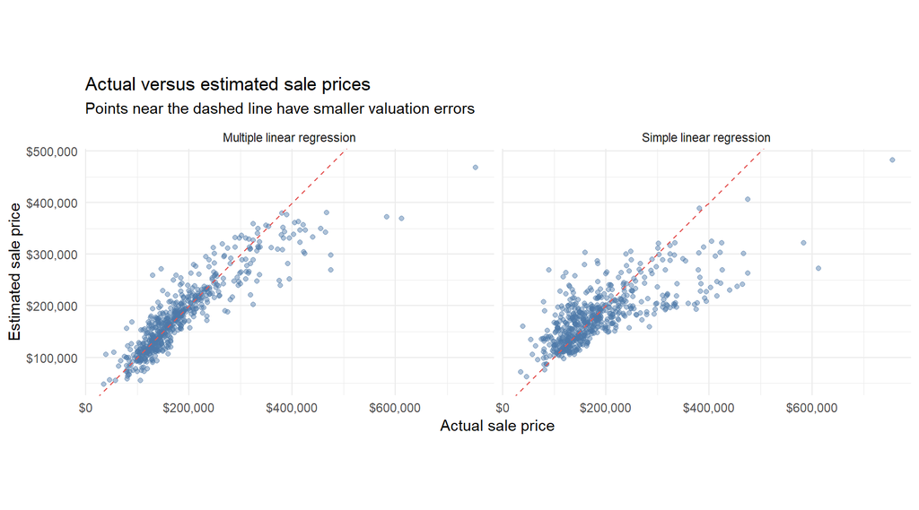

```r
bind_rows(
  simple_predictions |>
    mutate(model = "Simple linear regression"),
  multiple_predictions |>
    mutate(model = "Multiple linear regression")
) |>
  ggplot(aes(truth, .pred)) +
  geom_point(alpha = 0.45, color = "#4C78A8") +
  geom_abline(slope = 1, intercept = 0, color = "#E45756", linetype = "dashed") +
  facet_wrap(~ model) +
  coord_equal() +
  scale_x_continuous(labels = dollar) +
  scale_y_continuous(labels = dollar) +
  labs(
    title = "Actual versus estimated sale prices",
    subtitle = "Points near the dashed line have smaller valuation errors",
    x = "Actual sale price",
    y = "Estimated sale price"
  ) +
  theme_minimal()
```

# 9 8. Diagnose the multiple regression model

## 9.1 Residuals versus fitted values

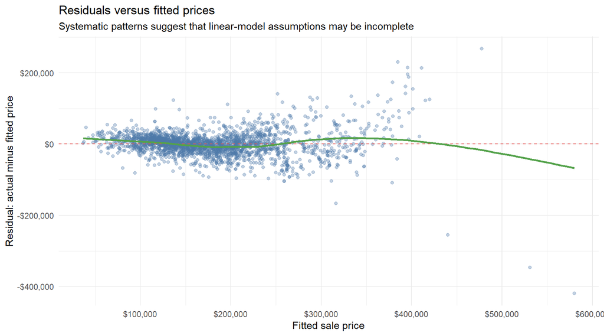

```r
augment(multiple_model) |>
  ggplot(aes(.fitted, .resid)) +
  geom_point(alpha = 0.35, color = "#4C78A8") +
  geom_hline(yintercept = 0, color = "#E45756", linetype = "dashed") +
  geom_smooth(se = FALSE, color = "#54A24B") +
  scale_x_continuous(labels = dollar) +
  scale_y_continuous(labels = dollar) +
  labs(
    title = "Residuals versus fitted prices",
    subtitle = "Systematic patterns suggest that linear-model assumptions may be incomplete",
    x = "Fitted sale price",
    y = "Residual: actual minus fitted price"
  ) +
  theme_minimal()
```

Operational interpretation:

- Residuals above zero represent underestimation.
- Residuals below zero represent overestimation.
- A widening spread at higher fitted prices suggests less consistent dollar accuracy for expensive properties.
- Curved patterns suggest nonlinear relationships or missing terms.

## 9.2 Normal Q-Q plot

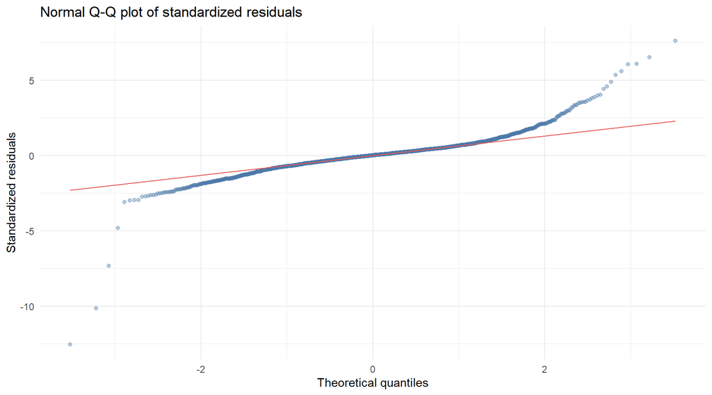

```r
augment(multiple_model) |>
  ggplot(aes(sample = .std.resid)) +
  stat_qq(alpha = 0.4, color = "#4C78A8") +
  stat_qq_line(color = "#E45756") +
  labs(
    title = "Normal Q-Q plot of standardized residuals",
    x = "Theoretical quantiles",
    y = "Standardized residuals"
  ) +
  theme_minimal()
```

## 9.3 Influential training observations

```r
influence_summary <- augment(multiple_model) |>
  mutate(training_row = row_number()) |>
  arrange(desc(.cooksd)) |>
  select(
    training_row,
    sale_price,
    .fitted,
    .resid,
    .std.resid,
    .hat,
    .cooksd
  ) |>
  slice_head(n = 10)

influence_summary
```

```
## # A tibble: 10 × 7
##    training_row sale_price .fitted   .resid .std.resid   .hat .cooksd
##           <int>      <int>   <dbl>    <dbl>      <dbl>  <dbl>   <dbl>
##  1          893     160000 579891. -419891.     -12.5  0.114   0.612
##  2         1625     183850 530809. -346959.     -10.2  0.0773  0.262
##  3         1626     184750 439976. -255226.      -7.32 0.0395  0.0668
##  4         2113     745000 477510.  267490.       7.63 0.0276  0.0500
##  5          812     150000 316396. -166396.      -4.82 0.0579  0.0433
##  6         2079     591587 395707.  195880.       5.58 0.0273  0.0265
##  7         2271     625000 411237.  213763.       6.07 0.0206  0.0235
##  8         1967     615000 384706.  230294.       6.53 0.0157  0.0205
##  9         2275     584500 396626.  187874.       5.34 0.0199  0.0175
## 10         2228     556581 401376.  155205.       4.42 0.0265  0.0161
```

Influential observations should be investigated, not automatically deleted. They may be valid high-value properties, data-quality problems, or market segments that require a different model.

# 10 9. Support valuation review

## 10.1 Properties with the largest test errors

```r
valuation_review <- test_data |>
  mutate(
    estimated_price = predict(multiple_model, newdata = test_data),
    residual = sale_price - estimated_price,
    absolute_error = abs(residual),
    error_direction = case_when(
      residual > 0 ~ "Model underestimated sale price",
      residual < 0 ~ "Model overestimated sale price",
      TRUE ~ "Exact estimate"
    )
  ) |>
  arrange(desc(absolute_error))

valuation_review |>
  select(
    sale_price,
    estimated_price,
    absolute_error,
    error_direction,
    gr_liv_area,
    year_built,
    neighborhood
  ) |>
  slice_head(n = 15)
```

```
## # A tibble: 15 × 7
##    sale_price estimated_price absolute_error error_direction         gr_liv_area
##         <int>           <dbl>          <dbl> <chr>                         <int>
##  1     755000         468207.        286793. Model underestimated s…        4316
##  2     611657         368741.        242916. Model underestimated s…        2364
##  3     582933         372164.        210769. Model underestimated s…        2822
##  4     475000         269816.        205184. Model underestimated s…        3608
##  5     475000         298723.        176277. Model underestimated s…        2276
##  6     395039         252025.        143014. Model underestimated s…        1766
##  7     377500         239664.        137836. Model underestimated s…        1746
##  8     130000         258688.        128688. Model overestimated sa…        1204
##  9     375000         248527.        126473. Model underestimated s…        1625
## 10     147000         271778.        124778. Model overestimated sa…        1795
## 11     424870         301158.        123712. Model underestimated s…        2828
## 12     465000         342109.        122891. Model underestimated s…        2076
## 13     325000         202373.        122627. Model underestimated s…        2775
## 14     423000         304428.        118572. Model underestimated s…        2097
## 15     392000         281557.        110443. Model underestimated s…        1824
## # ℹ 2 more variables: year_built <int>, neighborhood <fct>
```

These records form an **appraisal-review queue**, not proof that a transaction was incorrectly priced. Large errors may point to omitted features, exceptional property condition, unusual market circumstances, or data issues.

## 10.2 Provide a valuation range

A prediction interval communicates uncertainty for an individual property’s sale price. The example below calculates 95% prediction intervals for a small sample of test properties.

```r
interval_sample <- test_data |>
  slice_head(n = 10)

prediction_intervals <- predict(
  multiple_model,
  newdata = interval_sample,
  interval = "prediction",
  level = 0.95
) |>
  as_tibble() |>
  rename(
    estimated_price = fit,
    lower_estimate = lwr,
    upper_estimate = upr
  )

bind_cols(
  interval_sample |>
    select(sale_price, gr_liv_area, year_built, neighborhood),
  prediction_intervals
)
```

```
## # A tibble: 10 × 7
##    sale_price gr_liv_area year_built neighborhood estimated_price lower_estimate
##         <int>       <int>      <int> <fct>                  <dbl>          <dbl>
##  1     105000         896       1961 North_Ames           109935.         40065.
##  2     172000        1329       1958 North_Ames           148301.         78419.
##  3     189900        1629       1997 Gilbert              189050.        119028.
##  4     115000         864       1971 North_Ames            97589.         27614.
##  5     395192        1940       2009 Northridge_…         330884.        260839.
##  6     214000        1535       2004 Northridge_…         276713.        206652.
##  7     611657        2364       2009 Northridge_…         368741.        298649.
##  8     175500        1626       2003 Northridge_…         259280.        189165.
##  9     184500        1374       2004 Gilbert              160586.         90532.
## 10     333168        2599       1999 Northridge           340572.        270219.
## # ℹ 1 more variable: upper_estimate <dbl>
```

Prediction intervals are generally more appropriate for an individual property than confidence intervals for the average price. Their validity still depends on the model assumptions and similarity to the training market.

# 11 10. Operational recommendation questions

Use the generated results to answer:

1. What price should management use as a naive baseline, and why is it limited?
2. How much price difference is associated with an additional 100 square feet in the simple model?
3. How much of the training price variation is explained by living area alone?
4. How much do MAE and RMSE improve after adding other property characteristics?
5. Is the multiple model accurate enough for preliminary estimates? Define an acceptable error with business stakeholders before answering.
6. Does the model perform consistently across the price range?
7. Which large-error properties should appraisers investigate first?
8. Should the model produce a point estimate, a valuation range, or both?
9. What controls should prevent the estimate from being treated as an automatic final appraisal?

# 12 11. Recommended operational workflow

1. Validate incoming property measurements and category values.
2. Generate a preliminary estimate and prediction interval.
3. Route large, uncertain, or out-of-range valuations to an appraiser.
4. Record the appraiser’s adjustments and reasons.
5. Compare estimates with eventual sale prices using MAE, RMSE, MAPE, and bias.
6. Monitor error by neighborhood, price band, and property type.
7. Retrain or retire the model when market conditions or data definitions change.

# 13 12. Limitations

- Ames transactions represent a particular place and historical period.
- The selected predictors omit condition, remodeling, lot characteristics, and many other potentially important features available in the full dataset.
- Linear regression assumes additive, linear relationships unless terms are explicitly transformed or interacted.
- Neighborhood coefficients may absorb unmeasured local differences and should not be interpreted as causal neighborhood effects.
- A random split does not measure performance in a future housing market. A date-based validation is preferable before operational deployment.
- Extreme properties may require specialized appraisal rather than automated estimation.

# 14 13. Optional learner exercises

1. Fit a second simple regression using `year_built`. Is it more useful than living area alone?
2. Add `overall_qual` to the multiple model and evaluate the change in MAE and adjusted $R^2$.
3. Fit a model using `log(sale_price)` and compare residual patterns.
4. Test an interaction between living area and neighborhood.
5. Calculate mean error—not absolute error—to determine whether the model is systematically overestimating or underestimating prices.
6. Compare MAE across low-, middle-, and high-price segments.
7. Write a short recommendation for valuation managers that separates model evidence, operational judgment, and limitations.